# Fuel phenology regions for herbaceous fuels

A living project page: approach, analysis choices and preliminary results

Author

Mike Crimmins, University of Arizona Cooperative Extension

Published

October 6, 2026

**ImportantWork in progress**

This page tracks an ongoing analysis and is updated as the work moves along. Results shown here are **preliminary** and some come from a small Arizona test area. They are here to show the approach and invite feedback, not for operational use. The changelog lists what changed and when.

## At a glance

**The question.** Where across the contiguous U.S. do herbaceous fuels (grasses and forbs) share a common seasonal pattern of green-up, staying green and curing? Regions like that are the domains we need to build and tune **regional phenology models** for live fuel moisture, instead of applying one set of thresholds everywhere.

**The approach.** Two independent ways of drawing regions, then compare them:

- **Cut A, climate:** cluster grid cells on climate descriptors built from daily PRISM data. These regions are *hypotheses about what drives* fuel phenology.
- **Cut B, satellite curves:** cluster grid cells on the observed seasonal curves of greenness and canopy water from MODIS. This is the *response* and the real test of Cut A.
- **Ground observations** from the USA National Phenology Network (NPN) and iNaturalist provide an independent check, including in places where satellite curves and land-cover maps are hardest to interpret.

Where the climate and satellite regions agree, there is a solid basis for regional models. Where they disagree is where to look for what’s missing.

**Status (October 2026).**

Pipeline status

| Component | Status |
| --- | --- |
| Daily PRISM climate, 4 km, CONUS, 2001–2025 | Done |
| Grid, elevation and herbaceous cover layers (Annual NLCD) | Done |
| MODIS greenness and canopy water, CONUS, 2001–2025 | Downloading and processing |
| Cut A, Block 1: seasonal climate features | Built and checked on Arizona; CONUS run next |
| Cut A, Blocks 2 and 3: timing/variability and GSI features | Next (thresholds to decide) |
| Cut A clustering, first runs | Next |
| Cut B curve processing and clustering | Planned |
| NPN and iNaturalist observations | Planned (data inventory needed) |

## Why regions?

The Growing Season Index (GSI; Jolly et al. 2005) in the National Fire Danger Rating System turns daily minimum temperature, vapor pressure deficit and day length into an index of plant activity, which is then mapped to live fuel moisture. The same thresholds are applied everywhere, but herbaceous fuels in a desert grassland watered by the summer monsoon, a shortgrass prairie, and a California annual grassland respond to different cues on different calendars.

In discussions with fire managers and planners, the need that came up was **fuel phenology regionalization**: a data-driven way to find regions with roughly common green-up, maintenance and curing patterns, so that phenology models can be built and tuned within each one. We start with **herbaceous fuels** and draw regions **wall to wall across CONUS**. That way they can be tested anywhere, including in the East where land-cover maps are challenging, and ground observations anywhere can be used. The regions can later roll up to the two NFDRS live fuel classes.

## How the analysis is built

```
%%{init: {"themeVariables": {"fontSize": "17px"}}}%%
flowchart LR
  P["Daily PRISM 4 km<br/>ppt, tmin, tmax, vpdmax<br/>2001–2025"] --> B1["Block 1<br/>seasonal climate"]
  P --> B2["Block 2<br/>timing and variability"]
  P --> B3["Block 3<br/>GSI sub-indices"]
  B1 --> A["Cut A<br/>climate regions"]
  B2 --> A
  B3 --> A
  M["MODIS NDVI and NDII7<br/>Terra + Aqua, 1 km to 4 km"] --> C["Cut B<br/>seasonal-curve regions"]
  N["NLCD herbaceous cover"] -. "weights and mask" .-> A
  N -. "selects grass-dominated cells" .-> C
  A --> X{"Compare"}
  C --> X
  O["NPN and iNaturalist<br/>phenophase observations"] --> X
  X --> R["Fuel phenology regions<br/>for regional phenology models"]
```

Everything sits on the PRISM 4 km grid (about 480,000 land cells). Features are computed **for each year and then summarized across years** (median and year-to-year spread), never from an average-year climate: the GSI of an average year is not the average GSI.

### Data

Data sets

| Data set | What it provides | Resolution and period |
| --- | --- | --- |
| PRISM daily (Oregon State University) | Precipitation, min and max temperature, max vapor pressure deficit | 4 km, daily, 2001–2025 |
| MODIS MOD13A2 (Terra) and MYD13A2 (Aqua), Collection 6.1, via NASA AppEEARS | NDVI (greenness); NIR and MIR reflectance for NDII7 (canopy water and curing) | 1 km, 16-day composites, averaged to 4 km; 2001–2025 (Aqua from mid-2002) |
| Annual NLCD Collection 1 (USGS) | Grassland, shrub/scrub, pasture, crop shares per 4 km cell | 30 m land cover for 2001, 2012 and 2024 |
| USA-NPN and iNaturalist | Ground observations of phenophases (green-up, flowering, senescence) | Point observations, CONUS |

## Study domain and herbaceous cover

Regions cover all CONUS land. Herbaceous cover from Annual NLCD is used to **describe and weight** cells, not to define the domain. Two shares are kept: a *core* share (grassland plus shrub/scrub) and an *open* share that adds pasture and hay, which is the main herbaceous cover in the East. A **strict mask** (core share at least half of the land and crops under a quarter) picks out the cells where a MODIS curve is mostly a herbaceous signal. It is used to select Cut B curves and for sensitivity runs.

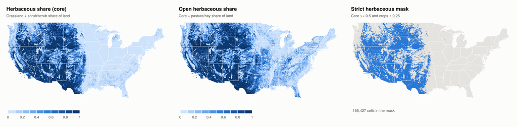

Figure 1: Herbaceous cover on the 4 km grid from Annual NLCD (mean of 2001, 2012 and 2024). The strict mask covers about a third of CONUS land, almost all of it in the West and Great Plains. CONUS · NLCD 2001, 2012, 2024 · figure made 2026-10-06

**TipWhy grassland and shrub are combined**

In NLCD the split between grassland/herbaceous and shrub/scrub changes abruptly at some state lines (for example Wyoming/Nebraska, Colorado/Kansas, New Mexico/Texas), a mapping artifact rather than a real change in vegetation. The analysis therefore only uses the combined share, never grassland alone.

## Cut A: climate features

The climate features come in three blocks, which are added one at a time so we can see what each contributes: **A1** = Block 1 + elevation and latitude, **A2** = A1 + Block 2, **A3** = A2 + Block 3. Keeping the GSI-based features in their own block answers a practical question: does the GSI formulation add information about where phenology differs, or do its thresholds steer the regions?

### Block 1: seasonal climate (built)

The year runs from October through September (a *water year*) for temperature, precipitation and aridity, because cool-season moisture comes before the green-up it feeds. Freeze dates and growing degree days use the calendar year.

Block 1 features (21 per year)

| Feature | Definition |
| --- | --- |
| Seasonal and annual temperature | Mean of daily (tmin + tmax)/2 for Oct–Dec, Jan–Mar, Apr–Jun, Jul–Sep and the water year; warmest-minus-coolest season range |
| Annual precipitation and seasonal shares | Water-year total and the fraction falling in each season (Jul–Sep isolates the monsoon; Apr–Jun the dry foresummer) |
| Aridity index | Precipitation / potential evapotranspiration (Hargreaves), for the water year and the warm season (Apr–Sep) |
| Freeze dates and freeze-free season | Last spring and first fall day with tmin ≤ 0 °C, and the days between them; ≤ −2.2 °C as a sensitivity check |
| Growing degree days | Base 5 °C (cool-season and general growth) and base 10 °C (warm-season grasses) |

**NoteFigure pending**

Six of the Block 1 features, as the median across years.

How a feature varies **from year to year** matters as much as its typical value: grasses in a place where summer rain is unreliable behave differently from grasses where it always arrives. Block 1 keeps the spread (interquartile range, IQR) of every feature alongside its median.

**NoteFigure pending**

Year-to-year spread of three Block 1 features (interquartile range across years; precipitation as IQR relative to the median).

**NoteReading the preliminary maps**

- Arizona test-area maps use only two water years, so they check that the processing works rather than describe the climate. The CONUS maps use 2002–2025.
- Where no freeze occurs, the freeze-free season is set to the full year, so the edge of the frost-free low desert appears as a sharp boundary.
- The aridity index is very skewed (most of the West is well below 1), so it will be log- or rank-transformed before clustering.

### Block 2: timing and variability (next)

Herbaceous phenology responds to the **timing and reliability** of moisture and warmth, not just the averages. Candidate features:

- onset of the warm-season rains (the first date a cumulative-precipitation threshold is passed) and how much it varies from year to year;
- frequency of rain pulses large enough to matter, and typical dry-spell length within the warm season;
- “false starts”: warm spells followed by a hard freeze;
- simple strata of what limits growth (cold, moisture, or both) from daily rules.

The freeze definition matches Block 1. The rain-event size and the onset rule are still to be decided.

### Block 3: GSI sub-indices (planned)

The daily GSI sub-indices (minimum temperature, vapor pressure deficit, day length and a moisture ramp), computed per year, give the share of the active season limited by each factor, and the onset, peak and decline dates of the smoothed index. PRISM has no soil moisture, so the moisture ramp will use a precipitation-based index or a simple water balance, and that choice will be treated as a sensitivity test. Vapor pressure deficit is the least reliable PRISM variable, so A3 will be run with and without it.

## Cut B: satellite seasonal curves

Cut B uses MODIS 16-day composites from both Terra and Aqua at 1 km, averaged to the 4 km grid using only good-quality pixels. The count of valid pixels and the share flagged as snow are kept for every composite. Two indices describe the season:

- **NDVI** for greenness;
- **NDII7** = (NIR − MIR) / (NIR + MIR) for canopy water content. It drops as grasses cure, often separating from NDVI when plants are still green but drying.

**NoteFigure pending**

16-day NDVI and NDII7 at sample grassland locations, Terra and Aqua.

**NoteFigure pending**

Size of the NDVI seasonal cycle and when it peaks, from one year of Terra composites. Cells with an amplitude under 0.1 have no clear green season.

Before clustering, the curves will be merged across Terra and Aqua (the two sensors differ slightly, especially in NDII7), gap-filled where clouds or snow leave holes, smoothed, and summarized per year (green-up, peak, curing dates and rates). The clustering itself will work on the shapes of whole curves (functional principal components).

## Clustering and evaluation plan

Methods will be judged by how well the regions work as domains for regional phenology models, not by clustering scores alone.

- **First runs (Cut A):** k-means as a baseline, Gaussian mixtures (soft membership shows transition zones), and Ward hierarchical clustering (nested regions: fine for modeling, coarse for operational roll-up). A spatially constrained version tests how much is lost by requiring contiguous regions.
- **Cut B:** functional PCA of the seasonal curves, then mixtures on the scores.
- **Linking A and B:** cluster the curves, then predict those regions from the climate features with random forests. This gives a wall-to-wall map and shows which climate features separate phenology regions.
- **Evaluation:** stability under resampling of years and space; agreement between the A1, A2, A3 and Cut B partitions; comparison with EPA ecoregions and operational units (Predictive Service Areas, NFDRS climate classes); and whether NPN and iNaturalist phenophase dates differ more between regions than within them.

## Decisions so far

Analysis decisions

| Date | Decision | Why |
| --- | --- | --- |
| Oct 2026 | Start with herbaceous fuels; regions are domains for regional phenology models | Most direct need raised by fire managers; herbaceous fuels respond fastest |
| Oct 2026 | Build Cut A from daily PRISM at 4 km; features per year, then summarized | Daily data capture timing and variability; averaging climate first distorts nonlinear indices like GSI |
| Oct 2026 | Herbaceous cover from Annual NLCD (grassland + shrub/scrub; 2001, 2012, 2024) | Consistent national product; combined share avoids the state-line artifact |
| Oct 2026 | Regions are wall to wall across CONUS | Lets NPN and iNaturalist observations anywhere test the regions; cover is an attribute, not the domain |
| Oct 2026 | Cut B from MODIS MOD13A2 + MYD13A2 (1 km, 16-day), averaged to 4 km; NDVI and NDII7 | Available nationally through AppEEARS; two sensors double the sampling; NDII7 tracks curing |
| Oct 2026 | Data period starts in 2001 | First full year of MODIS, so the climate and satellite cuts overlap |
| Oct 2026 | Block 1 definitions: water year, Oct–Dec/Jan–Mar/Apr–Jun/Jul–Sep seasons, GDD base 5 and 10 °C, freeze at 0 °C (−2.2 °C sensitivity), Hargreaves aridity | Seasons isolate the monsoon and the dry foresummer; bases fit cool- and warm-season grasses |
| Oct 2026 | Soils deferred | No quick national water-holding capacity layer; add if the first runs suggest it matters |

## Open questions for the team

- **Study period:** use all of 2001–2025, or a fixed recent window?
- **Block 2 thresholds:** what size of rain event matters to herbaceous fuels, and how should the onset of the warm-season rains be defined?
- **GSI moisture ramp:** which precipitation or water-balance index to use in Block 3?
- **Ground observations:** which NPN and iNaturalist taxa and phenophases best represent herbaceous fuel green-up and curing?
- **Operational use:** how contiguous do regions need to be to be useful to managers?
- **C3/C4 grasses:** is there a suitable national layer of cool- versus warm-season grass cover?

Comments on any of these are welcome.

## Changelog

| Date | Change |
| --- | --- |
| 2026-10-06 | Page created: approach, data, decisions, Block 1 features, first figures |

## Data sources and references

- PRISM Group, Oregon State University, https://prism.oregonstate.edu, daily 4 km data accessed October 2026.
- Didan, K. (2021). MOD13A2 and MYD13A2 MODIS/Terra and Aqua Vegetation Indices 16-Day L3 Global 1 km SIN Grid V061. NASA EOSDIS Land Processes DAAC. Accessed through AppEEARS (https://appeears.earthdatacloud.nasa.gov).
- U.S. Geological Survey. Annual National Land Cover Database (NLCD) Collection 1, https://www.mrlc.gov.
- USA National Phenology Network, https://www.usanpn.org; iNaturalist, https://www.inaturalist.org.
- Jolly, W. M., Nemani, R., and Running, S. W. (2005). A generalized, bioclimatic index to predict foliar phenology in response to climate. *Global Change Biology* 11, 619–632.
- Hargreaves, G. H., and Samani, Z. A. (1985). Reference crop evapotranspiration from temperature. *Applied Engineering in Agriculture* 1, 96–99.
- Allen, R. G., Pereira, L. S., Raes, D., and Smith, M. (1998). *Crop evapotranspiration*. FAO Irrigation and Drainage Paper 56.